# BST 260- Happy Highs

Seranne Motital, Shravanthi Seshasayee, Sanjana Sunderesan

10 December 2017

**Overview and Motivation**

[The World Happiness Report](http://worldhappiness.report/overview/) is a composite measure of country-level happiness based on economic and social factors such as per capita GDP, social support, healthy life expectancy at birth, freedom to make life choices, generosity and perceptions of corruption, released annually by the United Nations Sustainable Development Solutions Network. In the present landscape of shifting political and economic climates across the world, we believe it is important to expand and include measures which encompass a wider narrative of the human experience.

# WHR happiness index

```
## 154 codes from your data successfully matched countries in the map
## 3 codes from your data failed to match with a country code in the map
## 89 codes from the map weren't represented in your data
```

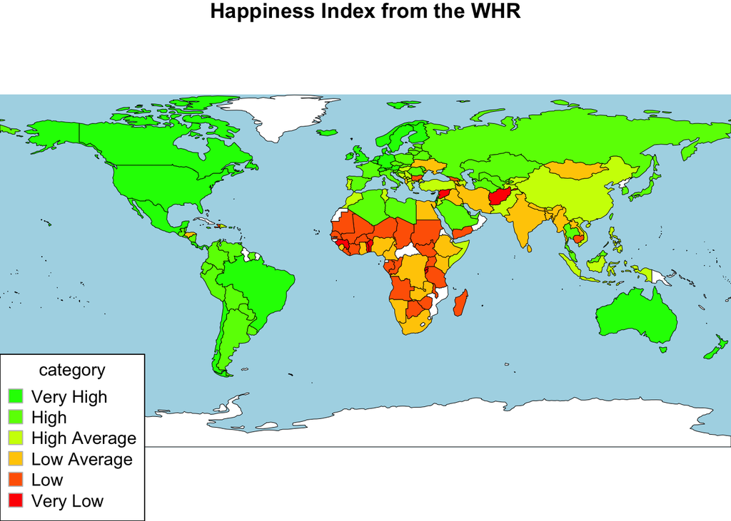

```r
whr <- read_csv("https://raw.githubusercontent.com/Seranne/IntroDSproject/master/Source%20Data/World%20Happiness%20Report/2016.csv")
colnames(whr)[3] <- "happiness.rank"
colnames(whr)[7] <- "gdp"


x <- whr %>% filter(!is.na(gdp)) %>% select("gdp")
x<- x$gdp
max(x)
```

```
## [1] 1.82427
```

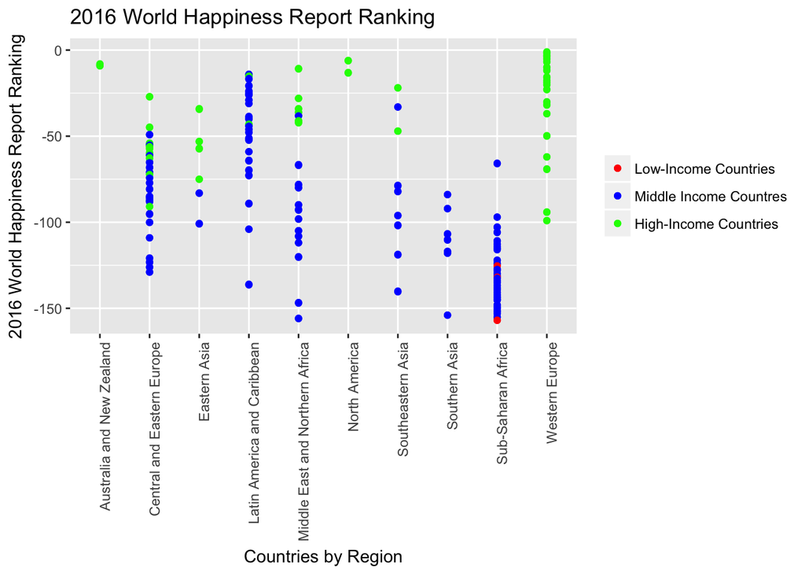

```r
x <- cut(as.numeric(x), c(0, 0.1005, 1.2236, 1.82427))
x = factor(x, labels = c("Low-Income Countries", "Middle Income Countres", "High-Income Countries"))

whr %>% ggplot(aes(x = Region, y = -happiness.rank, col = x)) + geom_point() + geom_jitter(width = 0, height = 0.5) + theme(axis.text.x = element_text(angle = 90, hjust = 1)) + scale_colour_manual(breaks = c("Low-Income Countries", "Middle Income Countres", "High-Income Countries"), values = c("red", "blue", "green")) + ylab("2016 World Happiness Report Ranking") + xlab("Countries by Region") + ggtitle("2016 World Happiness Report Ranking") + labs(colour = "")
```

We are keen to understand the association between country-level physical, financial, social, cultural, political, and environmental indicators and the parent country’s ranking on an overall well-being index. For instance, [literature](https://bmcpublichealth.biomedcentral.com/articles/10.1186/1471-2458-13-496) shows that “fear of crime represents a complex set of responses to the environment. It may play a role in mediating environmental impacts on health and wellbeing”. Conversely, in his [book](http://www.palgrave.com/us/book/9780333548080), “Politics, Women and Well-being”, Robin Jeffrey discusses the key role played by a more gender-equal society in the overall health and improvement of a state in India.

Similar to these findings, we strongly believe it is of great relevance to learn more about the influences of variables such as Gini Coefficients, literacy levels, deforestation, climate etc. on the happiness and well-being of a country as a whole.

We hope to understand the underlying variables most responsible for these scores, and identify conceptual and measurement gaps in the development of an overall score of country-level well-being. We believe that factors such as racial diversity, environmental sustainability, and population skew, among others, are either missing or underrepresented in the present composite measure. We aim to modify this to build a more well-rounded measure of the well-being of a country.  
We believe that this information could potentially inform policies to improve overall country happiness and human flourishing.

**Initial Questions:**

We began our project with the goal of identifying yearly-changes in a country’s happiness and well-being. However, as we learnt more about how these composite indices are derived, we grew keen to understand the factors considered in the creation of a well-being score. Over the course of our literature review, we identified more variables we believe are relevant to a population’s well-being, and decided to create a new, incremented ranking of country well-being with this additional data. Thus, our project seeks to answer:

Is there a change in the average ranking of a country’s happiness and well-being, given the inclusion of a more comprehensive variable list representing its physical, social, cultural, economic and political environments?

**Data:**

In order to develop our well-being index, we extracted data from a number of resources, categorized below:

```r
org = c("World Bank", "United Nations Sustainable Development Solutions Network", "New Economics Foundation", "Wikipedia (Fearon's Analysis)")
dat <- c("World Development Indicators (2010-17)", "World Happiness Report", "Happy Planet Index", "Ethnic Fractionalization Index")

datasources <- data.frame("Source" = org, "Data" = dat)
categs <- c("Child Welfare", "Gender", "Employment","Economic Indicators", "Energy Indicators", "Emissions", "Connectivity", "Environmental Welfare", "Food Deficit", "Sense of Security", "Travel for Leisure")

categs <- data.frame("Population Characteristics" = categs)

print(kable(datasources))
```

```
##
##
## Source                                                     Data
## ---------------------------------------------------------  ---------------------------------------
## World Bank                                                 World Development Indicators (2010-17)
## United Nations Sustainable Development Solutions Network   World Happiness Report
## New Economics Foundation                                   Happy Planet Index
## Wikipedia (Fearon's Analysis)                              Ethnic Fractionalization Index
```

```r
print(kable(categs))
```

```
##
##
## |Population.Characteristics |
## |:--------------------------|
## |Child Welfare              |
## |Gender                     |
## |Employment                 |
## |Economic Indicators        |
## |Energy Indicators          |
## |Emissions                  |
## |Connectivity               |
## |Environmental Welfare      |
## |Food Deficit               |
## |Sense of Security          |
## |Travel for Leisure         |
```

From each of our sources, we selected variables most relevant to the creation of our composite index (based on literature review). After a review of the [Handbook on Constructing Composite Score Indicators](https://www.oecd.org/std/42495745.pdf) released by the OECD examining weighting techniques in social and demographic index development, we decided to provide equal weightage to all variables, to provide countries with lesser-utilized variables equal opportunity to receive higher ranks in the final index.

A country-wise ranking was then generated for each variable, in every category. Every country then received a category-wise composite score, calculated as an equally-weighted average of the mean variable ranks.

**Methods:**

**Extracting data from the World Bank World Development Indicators**

The World Bank’s World Development Indicators were downloaded from [Kaggle](https://www.kaggle.com/worldbank/world-development-indicators), and this dataset is available for download as a .csv from [this link](https://drive.google.com/open?id=1ilfW3OIrVs6b4EsFPFbW-dw_vQiQgetU). However, given the large size of this data, our initial stage dataset is available as a smaller-sized url-linked csv (in the following code chunk), on which the rest of the code was run.

```r
# Replace path name with that of the downloaded csv file
Indicators_csv <- read_csv("Download/Path/Here.csv")

# Filter by Year
WDI <- filter(Indicators_csv, Year == "2010"| Year == "2011" | Year == "2012"| Year == "2013" | Year == "2014" | Year == "2015" | Year == "2016" | Year =="2017")

# Remove Aggregated Country classifications, by country code
WDInew <- filter(WDI, CountryCode != "WBG")
WDInew <- filter(WDInew, CountryCode != "WLD")
WDInew <- filter(WDInew, CountryCode != "UMC")
WDInew <- filter(WDInew, CountryCode != "SST")
WDInew <- filter(WDInew, CountryCode != "SSF")
WDInew <- filter(WDInew, CountryCode != "SSA")
WDInew <- filter(WDInew, CountryCode != "SAS")
WDInew <- filter(WDInew, CountryCode != "OSS")
WDInew <- filter(WDInew, CountryCode != "OED")
WDInew <- filter(WDInew, CountryCode != "MNA")
WDInew <- filter(WDInew, CountryCode != "MEA")
WDInew <- filter(WDInew, CountryCode != "LMC")
WDInew <- filter(WDInew, CountryCode != "LIC")
WDInew <- filter(WDInew, CountryCode != "LMY")
WDInew <- filter(WDInew, CountryCode != "LDC")
WDInew <- filter(WDInew, CountryCode != "LAC")
WDInew <- filter(WDInew, CountryCode != "LCN")
WDInew <- filter(WDInew, CountryCode != "OEC")
WDInew <- filter(WDInew, CountryCode != "NOC")
WDInew <- filter(WDInew, CountryCode != "NAC")
WDInew <- filter(WDInew, CountryCode != "MIC")
WDInew <- filter(WDInew, CountryCode != "HIC")
WDInew <- filter(WDInew, CountryCode != "HPC")
WDInew <- filter(WDInew, CountryCode != "FCS")
WDInew <- filter(WDInew, CountryCode != "EUU")
WDInew <- filter(WDInew, CountryCode != "ECA")
WDInew <- filter(WDInew, CountryCode != "ECS")
WDInew <- filter(WDInew, CountryCode != "EMU")
WDInew <- filter(WDInew, CountryCode != "EAP")
WDInew <- filter(WDInew, CountryCode != "EAS")
WDInew <- filter(WDInew, CountryCode != "CEB")
WDInew <- filter(WDInew, CountryCode != "ARB")

# Filter dataset to only include variables of interest
WDI2 <- filter(WDInew, IndicatorCode == "AG.LND.FRST.ZS" | IndicatorCode == "EG.FEC.RNEW.ZS"|IndicatorCode == "EG.USE.COMM.FO.ZS"|IndicatorCode == "EG.ELC.ACCS.ZS"|IndicatorCode == "EG.USE.ELEC.KH.PC"| IndicatorCode == "EN.ATM.CO2E.PC"|IndicatorCode == "ER.PTD.TOTL.ZS"| IndicatorCode == "EN.POP.DNST"|IndicatorCode == "ER.PTD.TOTL.ZS"|IndicatorCode == "FP.CPI.TOTL.ZG"|IndicatorCode == "GC.XPN.COMP.ZS"|IndicatorCode == "IC.FRM.CRIM.ZS"|IndicatorCode == "IC.FRM.FEMM.ZS"|IndicatorCode == "IC.LGL.CRED.XQ"|IndicatorCode == "IT.CEL.SETS.P2"|IndicatorCode == "IT.NET.USER.P2"|IndicatorCode == "MS.MIL.XPND.GD.ZS"|IndicatorCode == "NY.GDP.PCAP.CD"|IndicatorCode == "NY.GDP.MKTP.PP.CD"|IndicatorCode == "NY.GDP.PCAP.KD.ZG"|IndicatorCode == "SE.ADT.1524.LT.ZS"|IndicatorCode == "SE.ADT.LITR.ZS"|IndicatorCode == "SG.GEN.PARL.ZS"|IndicatorCode == "SG.VAW.REAS.ZS"|IndicatorCode == "SH.DTH.MORT"|IndicatorCode == "SI.POV.GINI"|IndicatorCode == "SL.EMP.WORK.ZS"|IndicatorCode == "SL.FAM.0714.ZS"|IndicatorCode == "SP.DYN.IMRT.IN"|IndicatorCode == "SL.UEM.NEET.ZS"|IndicatorCode == "SM.POP.TOTL.ZS"|IndicatorCode == "SN.ITK.DFCT"|IndicatorCode == "SP.DYN.LE00.IN"|IndicatorCode == "SP.UWT.TFRT"|IndicatorCode == "ST.INT.DPRT"|IndicatorCode == "SP.POP.TOTL"|IndicatorCode == "VC.IHR.PSRC.P5")

write.csv(WDI2, file = "ourWDI.csv")
```

If the above original dataset was not downloaded, the code below runs on the .csv generated at the end of the above code chunk

```r
# Load dataset
url <- "https://raw.githubusercontent.com/Seranne/IntroDSproject/master/ourWDI.csv"
WDI4 <- read.csv(url)
WDI4<- select(WDI4,"CountryName","CountryCode", "IndicatorCode", "Year","Value")

# Change Country Names to standard names
levels(WDI4$CountryName)[levels(WDI4$CountryName) == "Micronesia, Fed. Sts."] <- "Micronesia"
levels(WDI4$CountryName)[levels(WDI4$CountryName) == "United States"] <- "United States of America"
levels(WDI4$CountryName)[levels(WDI4$CountryName) == "Congo, Rep."] <- "Republic of Congo"
levels(WDI4$CountryName)[levels(WDI4$CountryName) == "Russian Federation"] <- "Russia"
levels(WDI4$CountryName)[levels(WDI4$CountryName) == "Congo, Dem. Rep."] <- "Democratic Republic of Congo"
levels(WDI4$CountryName)[levels(WDI4$CountryName) == "Eygpt, Arab Rep."] <- "Egypt"
levels(WDI4$CountryName)[levels(WDI4$CountryName) == "Iran, Islamic Rep."] <- "Iran"
levels(WDI4$CountryName)[levels(WDI4$CountryName) == "Korea, Dem. Rep"] <- "North Korea"
levels(WDI4$CountryName)[levels(WDI4$CountryName) == "Korea, Rep."] <- "South Korea"
levels(WDI4$CountryName)[levels(WDI4$CountryName) == "Kyrgyz Republic"] <- "Kyrgyzstan"
levels(WDI4$CountryName)[levels(WDI4$CountryName) == "Slovak Republic"] <- "Slovakia"
levels(WDI4$CountryName)[levels(WDI4$CountryName) == "Syrian Arab Republic"] <- "Syria"
levels(WDI4$CountryName)[levels(WDI4$CountryName) == "China & Hong Kong SAR, China"] <- "Hong Kong"
levels(WDI4$CountryName)[levels(WDI4$CountryName) == "Macedonia, FYR"] <- "Macedonia"
levels(WDI4$CountryName)[levels(WDI4$CountryName) == "Bahamas, The"] <- "Bahamas"
levels(WDI4$CountryName)[levels(WDI4$CountryName) == "Gambia, The"] <- "Gambia"
levels(WDI4$CountryName)[levels(WDI4$CountryName) == "Venezuela, RB"] <- "Venezuela"
levels(WDI4$CountryName)[levels(WDI4$CountryName) == "Yemen, Rep."] <- "Yemen"
```

**Generating Category scores for each country**

After selecting the indicators of interest from the shortened WDI dataset, we created individual scores for each category based on the rank that a country achieved for the included variables.

Composite Energy Score: This score is based on Access to Electricity (% of population), Renewable Energy Consumption (% of final energy consumption), and Fossil fuel energy consumption (% of final energy consumption)

```r
# Selecting indicators of interest
Energy <- WDI4%>% filter(IndicatorCode == "EG.FEC.RNEW.ZS"|IndicatorCode == "EG.USE.COMM.FO.ZS"|IndicatorCode == "EG.ELC.ACCS.ZS"|IndicatorCode == "EG.USE.ELEC.KH.PC") %>% spread(IndicatorCode, Value)

#removing rows with NA Variables >  and filling in remaining na's with same country means
 Energy <- Energy[order(-Energy$Year),]
 Energy <- Energy[rowSums(is.na(Energy)) < ncol(Energy)/2, ]
 Energy<- aggregate(x=Energy[c("EG.ELC.ACCS.ZS","EG.FEC.RNEW.ZS","EG.USE.COMM.FO.ZS","EG.USE.ELEC.KH.PC")], by=list(name=Energy$CountryName), FUN = "mean" , na.rm = TRUE)
 colnames(Energy)[1] <- "CountryName"
 Energy <- Energy%>% distinct(CountryName, .keep_all = TRUE)

 # Access to Electricity (% of population); Highest score gets ranked 1
 Energy1<- select(Energy, "CountryName",  "EG.ELC.ACCS.ZS")
 Energy1 <- Energy1 %>% mutate(finalrank_eng1 = rank(-Energy1$EG.ELC.ACCS.ZS))
 Energy1$finalrank_eng1<- as.numeric(as.factor(Energy1$finalrank_eng1))

  # Renewable Energy Consumption (% of final energy consumption); Highest percentage gets ranked 1

 Energy2<- select(Energy, "CountryName",  "EG.FEC.RNEW.ZS")
 Energy2 <- Energy2 %>% mutate(finalrank_eng2 = rank(-Energy2$EG.FEC.RNEW.ZS))
 Energy2$finalrank_eng2<- as.numeric(as.factor(Energy2$finalrank_eng2))

  # Fossil fuel energy consumption (% of total);lowest consumption ranked 1

 Energy3<- select(Energy, "CountryName",  "EG.USE.COMM.FO.ZS")
 Energy3 <- Energy3 %>% mutate(finalrank_eng3 = rank(Energy3$EG.USE.COMM.FO.ZS))
 Energy3$finalrank_eng3<- as.numeric(as.factor(Energy3$finalrank_eng3))


 Enjoin <- left_join(Energy1, Energy2, "CountryName")
 Energy<- left_join(Enjoin, Energy3, "CountryName")
 Energy<- select(Energy,"CountryName", "finalrank_eng1", "finalrank_eng2", "finalrank_eng3")


# Highest aggregate score is ranked 1
Energy_score <- Energy %>% mutate(score_eng = (finalrank_eng1 + finalrank_eng2 + finalrank_eng3 )/3)
Energy_score <- Energy_score %>% mutate(finalrank_eng = rank(Energy_score$score_eng))

Energy_score <- Energy_score %>% select("CountryName", "finalrank_eng")

en_s <- Energy_score
colnames(en_s)[2] <- "Composite_Energy_Rank"

en_s %>%
   arrange(Composite_Energy_Rank) %>%
   slice(1:5)
```

```
## # A tibble: 5 x 2
##   CountryName Composite_Energy_Rank
##        <fctr>                 <dbl>
## 1     Iceland                     1
## 2  Tajikistan                     2
## 3       Nepal                     3
## 4      Sweden                     4
## 5    Paraguay                     5
```

These scores reflect an aggregrate of least fossil fuel energy consumption, and most proportion of renewable energy consumption - the results of which aligned with our expectations given that the top 5 countries are largely smaller in size, and also have relatively smaller populations.

CO2 Emissions score:

```r
# Select indicator variable: CO2 emissions (metric tons per capita)
emissions <- WDI4%>% filter(IndicatorCode == "EN.ATM.CO2E.PC")%>% spread(IndicatorCode, Value)

# Lowest score gets ranked 1
emissions_score <- emissions %>%
  group_by(CountryName) %>%
  summarise(mean_CO2 = mean(EN.ATM.CO2E.PC)) %>%
  na.omit() %>%
  mutate(finalrank_emission = rank(mean_CO2))

escore <- emissions_score %>% select("CountryName", "finalrank_emission")
em_s <- escore
colnames(em_s)[2] <- "Composite_Emissions_Rank"

em_s %>%
   arrange(Composite_Emissions_Rank) %>%
   slice(1:5)
```

```
## # A tibble: 5 x 2
##                    CountryName Composite_Emissions_Rank
##                         <fctr>                    <dbl>
## 1                      Burundi                        1
## 2                         Chad                        2
## 3 Democratic Republic of Congo                        3
## 4                       Rwanda                        4
## 5     Central African Republic                        5
```

This score reflects lowest CO2 emissions in the world. We believe that this data reflects countries which are more agricultural than industrial, and also ones with relatively smaller population sizes.

Composite Environmental well-being score: This score is based on the proportion of protected areas: both Terrestrial and Marine protected areas (% of total territorial area), and Forest area(% land area)

```r
# Selecting indicator variables: Terrestrial and marine protected areas (% of total territorial area) and Forest area (% of land area)

envir <- WDI4 %>% filter(IndicatorCode == "ER.PTD.TOTL.ZS"|IndicatorCode == "AG.LND.FRST.ZS") %>% spread(IndicatorCode, Value)

# Highest score gets ranked 1
environment_score <- envir %>%
  group_by(CountryName) %>%
  na.omit() %>%
  summarise(mean_agland = mean(AG.LND.FRST.ZS), mean_protect = mean(ER.PTD.TOTL.ZS)) %>%
  mutate(rank_agland = rank(mean_agland), rank_protect = rank(mean_protect)) %>%
  mutate(score = (rank_agland+rank_protect)/2) %>%
  mutate(finalrank_env = rank(-score)) %>%
  select("CountryName", "finalrank_env")

env_s <- environment_score
colnames(env_s)[2] <- "Composite_Environment_Rank"

env_s  %>%
   arrange(Composite_Environment_Rank) %>%
   slice(1:5)
```

```
## # A tibble: 5 x 2
##         CountryName Composite_Environment_Rank
##              <fctr>                      <dbl>
## 1          Slovenia                          1
## 2            Zambia                          2
## 3 Brunei Darussalam                          3
## 4             Palau                          4
## 5            Bhutan                          5
```

Communication/Connectivity score: This score is based on Mobile Cellular subscriptions (per 100 people) and Internet Users (per 100 people)

```r
# Score based on Mobile cellular subscriptions (per 100 people) and Internet Users (per 100 people)
# Highest score gets ranked 1

Communication <- WDI4 %>% filter(IndicatorCode == "IT.CEL.SETS.P2"|IndicatorCode == "IT.NET.USER.P2")  %>% spread(IndicatorCode, Value)
 Communication <- Communication[order(-Communication$Year),]
 Communication <- Communication[rowSums(is.na(Communication)) < ncol(Communication)/2, ]
 Communication<- aggregate(x=Communication[c("IT.CEL.SETS.P2","IT.NET.USER.P2")], by=list(name=Communication$CountryName), FUN = "mean" , na.rm = TRUE)
 colnames(Communication)[1] <- "CountryName"
Communication <- Communication %>% mutate(rankcell = rank(IT.CEL.SETS.P2))
Communication <- Communication %>% mutate(ranknet = rank(IT.NET.USER.P2))
Communication <- Communication %>% mutate(score = (rankcell+ranknet)/2)
Communication <- Communication %>% mutate(finalrank_comm = rank(-Communication$score))
Communication_score <- select(Communication, "CountryName", "finalrank_comm" )

com_s <-Communication_score
colnames(com_s)[2] <- "Composite_Communications_Rank"

com_s %>%
   arrange(Composite_Communications_Rank) %>%
   slice(1:5)
```

```
## # A tibble: 5 x 2
##            CountryName Composite_Communications_Rank
##                 <fctr>                         <dbl>
## 1              Finland                             1
## 2           Luxembourg                             2
## 3 Hong Kong SAR, China                             3
## 4              Curacao                             4
## 5 United Arab Emirates                             5
```

Composite Child Welfare score: Based on share of children not in education, employment or training, and Infant Mortality Rate

```r
children<- WDI4 %>% filter(IndicatorCode == "SL.FAM.0714.ZS"|IndicatorCode == "SL.UEM.NEET.ZS" | IndicatorCode == "SP.DYN.IMRT.IN") %>% spread(IndicatorCode, Value)

# Share of children not in education, employment or training: lowest score gets ranked 1
neet <- select(children, "CountryName", "Year", "SL.UEM.NEET.ZS")
neet <- neet[order(-neet$Year),]
neet <- na.omit(neet)
neet <- neet %>% distinct(CountryName, .keep_all = TRUE)

# Infant mortality rate: lowest score gets ranked 1
imr <- select(children, "CountryName", "Year", "SP.DYN.IMRT.IN")
imr <- imr[order(-imr$Year),]
imr <- na.omit(imr)
imr <- imr %>% distinct(CountryName, .keep_all = TRUE)
imr <- mutate(imr, rank.imr = as.numeric(as.factor(rank((SP.DYN.IMRT.IN)))))

# Lowest aggregrate score gets ranked 1, indicating best child welfare score

childwelfare <- left_join(imr, neet, by = "CountryName")
childwelfare <- select(childwelfare, "CountryName", "SL.UEM.NEET.ZS", "SP.DYN.IMRT.IN", "rank.imr")

# Filling missing values in NEET using average of othercountry NEET scores
avgneet <- mean(neet$SL.UEM.NEET.ZS)
childwelfare$SL.UEM.NEET.ZS[is.na(childwelfare$SL.UEM.NEET.ZS)] <- avgneet
childwelfare <- mutate(childwelfare, rank.neet = as.numeric(as.factor(rank((SL.UEM.NEET.ZS)))))
childwelfare_score <- mutate(childwelfare, finalscore_child = as.numeric
                       (as.factor(rank(((rank.neet+rank.imr)/2)))))

childwelfare_score <- childwelfare_score %>% select("CountryName","finalscore_child")

chld_s <- childwelfare_score

colnames(chld_s)[2] <- "Composite_ChildWelfare_Rank"

chld_s %>%
   arrange(Composite_ChildWelfare_Rank) %>%
   slice(1:5)
```

```
## # A tibble: 5 x 2
##   CountryName Composite_ChildWelfare_Rank
##        <fctr>                       <dbl>
## 1       Japan                           1
## 2      Norway                           2
## 3     Iceland                           3
## 4  Luxembourg                           4
## 5     Denmark                           5
```

Food Deficit score: Assessed by the depth of the food deficit (kilocalories per person per day), and returned as ranks with the least depth of food deficit

```r
# Load dataset and select indicator
deficit <- WDI4 %>% filter(IndicatorCode == "SN.ITK.DFCT") %>% spread(IndicatorCode, Value)

# Country with the least food deficit will rank 1
deficit <- select(deficit, "CountryName", "Year", "SN.ITK.DFCT")
deficit <- deficit[order(-deficit$Year),]
deficit <- deficit %>% distinct(CountryName, .keep_all = TRUE)

deficit.score = as.numeric(as.factor(rank((deficit$SN.ITK.DFCT))))
deficit_score <- deficit %>% mutate(finalrank_deficit =
                                as.numeric(as.factor(rank((deficit$SN.ITK.DFCT)))))

deficit_score <- deficit_score %>% select("CountryName", "finalrank_deficit")

def_s <- deficit_score
colnames(def_s)[2] <- "Composite_Deficit_Rank"

def_s  %>%
   arrange(Composite_Deficit_Rank) %>%
   slice(1:5)
```

```
## # A tibble: 5 x 2
##   CountryName Composite_Deficit_Rank
##        <fctr>                  <dbl>
## 1      Turkey                      1
## 2     Tunisia                      2
## 3   Argentina                      3
## 4 South Korea                      3
## 5        Cuba                      4
```

Economic score: This is assessed by assigning positive correlations between a higher rank and higher GDP per capita (in USD), GDP per capita, PPP (in current international dollar), GDP per capita growth (annual %). The ranks are also negatively correlated with Military Expenditure (% of GDP) and Inflation (annual %).

```r
# Selecting relevant economic indicators
GDP_base <- WDI4 %>% filter(IndicatorCode == "MS.MIL.XPND.GD.ZS"|IndicatorCode == "NY.GDP.PCAP.CD"|IndicatorCode == "NY.GDP.MKTP.PP.CD"|IndicatorCode == "NY.GDP.PCAP.KD.ZG"|IndicatorCode == "FP.CPI.TOTL.ZG") %>% spread(IndicatorCode, Value)

#Individual data frames for each variable of GDP

#Military expenditure (% of GDP) - Lowest expenditure will be ranked 1
gdp_1 <- GDP_base %>%
  select(CountryName, Year, MS.MIL.XPND.GD.ZS) %>%
  na.omit() %>%
  group_by(CountryName) %>%
  summarise(mean_mil = mean(MS.MIL.XPND.GD.ZS)) %>%
  mutate(finalrank_mil = rank(mean_mil))

#GDP per capita (in USD) - Country with the highest GDP will be ranked 1
gdp_2 <- GDP_base %>%
  select(CountryName, Year, NY.GDP.MKTP.PP.CD) %>%
  na.omit() %>%
  group_by(CountryName) %>%
  summarise(mean_ppp = mean(NY.GDP.MKTP.PP.CD)) %>%
  mutate(finalrank_ppp = rank(-mean_ppp))

#GDP per capita, PPP (in current international dollar) - Country with the highest GDP will be ranked 1
gdp_3 <- GDP_base %>%
  select(CountryName, Year, NY.GDP.PCAP.CD) %>%
  na.omit() %>%
  group_by(CountryName) %>%
  summarise(mean_gdp = mean(NY.GDP.PCAP.CD)) %>%
  mutate(finalrank_gdp = rank(-mean_gdp))

#GDP per capita growth (annual %) - Country with highest GDP will be ranked 1
gdp_4 <- GDP_base %>%
  select(CountryName, Year, NY.GDP.PCAP.KD.ZG) %>%
  na.omit() %>%
  group_by(CountryName) %>%
  summarise(mean_gdpg = mean(NY.GDP.PCAP.KD.ZG)) %>%
  mutate(finalrank_gdpg = rank(-mean_gdpg))

#Inflation (annual %) - Country with the lowest annual inflation % will rank 1
gdp_5 <- GDP_base %>%
  select(CountryName, Year, FP.CPI.TOTL.ZG) %>%
  na.omit() %>%
  group_by(CountryName) %>%
  summarise(mean_infl = mean(FP.CPI.TOTL.ZG)) %>%
  mutate(finalrank_infl = rank(mean_infl))

#Joining the ranks from all of the variables
GDP_a <- left_join(gdp_1, gdp_2, "CountryName")
GDPjoin <- left_join(GDP_a, gdp_3, "CountryName")
GDPjoin <- left_join(GDPjoin, gdp_4, "CountryName")
GDPjoin <- left_join (GDPjoin, gdp_5, "CountryName")
GDP2 <- GDPjoin %>% select(CountryName, finalrank_mil, finalrank_ppp, finalrank_gdp, finalrank_gdpg, finalrank_infl)

GDP2 <- GDP2[rowSums(is.na(GDP2)) < 4, ]
i <- which(is.na(GDP2), arr.ind = TRUE)
GDP2[i] <- rowMeans(GDP2[,-1], na.rm = TRUE)[i[,1]]

# Country with the highest average score will rank 1
GDP2 <- GDP2 %>% mutate(score_gdp = (finalrank_mil + finalrank_ppp+ finalrank_gdp + finalrank_gdpg + finalrank_infl)/5)

economy_score <- GDP2 %>% mutate(finalrank_GDP = rank(GDP2$score_gdp))

economy_score <- economy_score %>% select("CountryName", "finalrank_GDP")

es <- economy_score

colnames(es)[2] <- "Composite_Economic_Rank"
es %>%
   arrange(Composite_Economic_Rank) %>%
   slice(1:5)
```

```
## # A tibble: 5 x 2
##   CountryName Composite_Economic_Rank
##        <fctr>                   <dbl>
## 1       Japan                       1
## 2     Ireland                       2
## 3 Switzerland                       3
## 4     Germany                       4
## 5      Sweden                       5
```

Education score: Assessed as an average aggregate of Youth literacy rate, population 15-24 years, both sexes (%) and Adult literacy rate, population 15+ years, both sexes (%)

```r
# Selecting relevant indicator variables:

Education <- WDI4 %>% filter(IndicatorCode == "SE.ADT.1524.LT.ZS"|IndicatorCode == "SE.ADT.LITR.ZS") %>% spread(IndicatorCode, Value)

# Highest rate of youth literacy will be ranked 1
En1<- select(Education, "CountryName", "CountryCode", "Year", "SE.ADT.1524.LT.ZS")
En1 <- En1[order(-En1$Year),]
En1<- na.omit(En1)
En1 <- En1%>% distinct(CountryName, .keep_all = TRUE)
En1 <- En1 %>% mutate(rank_eng1 = rank(-En1$SE.ADT.1524.LT.ZS))
En1$rank_eng1<- as.numeric(as.factor(En1$rank_eng1))

# Highest rate of adult literacy will be ranked 1
En2<- select(Education, "CountryName", "CountryCode", "Year", "SE.ADT.LITR.ZS")
En2 <- En2[order(-En2$Year),]
En2<- na.omit(En2)
En2 <- En2%>% distinct(CountryName, .keep_all = TRUE)
En2 <- En2 %>% mutate(rank_eng2 = rank(-En2$SE.ADT.LITR.ZS))
En2$rank_eng2<- as.numeric(as.factor(En2$rank_eng2))

# Country with the highest average literacy rte will be ranked 1
litjoin <- left_join(En1, En2, "CountryName")
Education <- select(litjoin,"CountryName", "rank_eng1", "rank_eng2")
Education <- Education%>% mutate(score_edu = (rank_eng1 + rank_eng2)/2)
Education_score <- Education %>% mutate(finalrank_edu = rank(Education$score_edu)) %>% select("CountryName", "finalrank_edu")

ed_s<-Education_score
colnames(ed_s)[2] <- "Composite_Education_Rank"

ed_s %>%
   arrange(Composite_Education_Rank) %>%
   slice(1:5)
```

```
## # A tibble: 5 x 2
##   CountryName Composite_Education_Rank
##        <fctr>                    <dbl>
## 1     Estonia                      1.0
## 2  Azerbaijan                      2.5
## 3      Poland                      2.5
## 4        Cuba                      5.0
## 5      Latvia                      5.0
```

Gender score: Assessed by proportion of seats held by women in national parliaments (%)

```r
# Select indicator variable to assess gender equity: Proportion of seats held by women in national parliaments (%)

gender <- WDI4 %>% filter(IndicatorCode == "SG.GEN.PARL.ZS") %>% spread(IndicatorCode, Value)

gender <- select(gender, "CountryName", "CountryCode", "Year", "SG.GEN.PARL.ZS")
gender <- gender[order(-gender$Year),]
gender <- na.omit(gender)
gender <- gender%>% distinct(CountryName, .keep_all = TRUE)
Gender_score <- gender %>% mutate(finalrank_gen = rank(-gender$SG.GEN.PARL.ZS))
Gender_score$finalrank_gen<- as.numeric(as.factor(Gender_score$finalrank_gen))

Gender_score <- Gender_score %>% select("CountryName", "finalrank_gen")

gs <- Gender_score
colnames(gs)[2] <- "Composite_Gender_Rank"

gs %>%
   arrange(Composite_Gender_Rank) %>%
   slice(1:5)
```

```
## # A tibble: 5 x 2
##   CountryName Composite_Gender_Rank
##        <fctr>                 <dbl>
## 1      Rwanda                     1
## 2     Bolivia                     2
## 3        Cuba                     3
## 4  Seychelles                     4
## 5      Sweden                     5
```

An interesting finding from our ranking, is the fact that Rwanda ranks No. 1 in the list of countries with the highest proportion of women in their parliaments. This is likely a reflection of its traditionally matriarchal society, increasing equity in gender roles in the country. [More](https://www.thedailybeast.com/two-decades-after-genocide-rwandas-women-have-made-the-nation-thrive) on this [here](https://kristof.blogs.nytimes.com/2008/10/07/when-it-comes-to-women-lawmakers-rwanda-leads-the-world/).

Employment score: Assessed by Wage and salaried workers, total (% of total employed)

```r
# Select indicator variable
# country with the highest % of wage and salaried workers will be ranked 1

empl<- WDI4 %>% filter(IndicatorCode == "SL.EMP.WORK.ZS") %>% spread(IndicatorCode, Value)
empl <- select(empl, "CountryName", "Year", "SL.EMP.WORK.ZS")
empl <- empl[order(-empl$Year),]
empl <- empl %>% distinct(CountryName, .keep_all = TRUE)

employment_score <- empl %>% mutate(finalrank_empl =
                          as.numeric(as.factor(rank(-(empl$SL.EMP.WORK.ZS))))) %>% select("CountryName", "finalrank_empl")

emp_s <- employment_score
colnames(emp_s)[2] <- "Composite_Employment_Rank"

emp_s %>%
   arrange(Composite_Employment_Rank) %>%
   slice(1:5)
```

```
## # A tibble: 5 x 2
##      CountryName Composite_Employment_Rank
##           <fctr>                     <dbl>
## 1          Qatar                         1
## 2 American Samoa                         2
## 3         Kuwait                         3
## 4        Bahrain                         3
## 5          Kenya                         4
```

Population score: Final rank is positively correlated lower population density, lower GINI indices and higher life expectancies at birth

```r
# Select relevant indicator variables

Population <- WDI4 %>% filter(IndicatorCode == "SI.POV.GINI"|IndicatorCode == "SM.POP.TOTL.ZS"|IndicatorCode == "SP.DYN.LE00.IN" | IndicatorCode == "SP.POP.TOTL"| IndicatorCode == "EN.POP.DNST") %>% spread(IndicatorCode, Value)

 Population <- Population[order(-Population$Year),]
 Population <- Population[rowSums(is.na(Population)) < ncol(Population)/2, ]
 Population<- aggregate(x=Population[c("EN.POP.DNST","SI.POV.GINI","SM.POP.TOTL.ZS","SP.DYN.LE00.IN", "SP.POP.TOTL")], by=list(name=Population$CountryName), FUN = "mean" , na.rm = TRUE)

 colnames(Population)[1] <- "CountryName"
Population <- Population[rowSums(is.na(Population)) < ncol(Population)/2, ]
 Population <- Population%>% distinct(CountryName, .keep_all = TRUE)

# Population density (people per sq. km of land area): Lowest ranked 1
 Population1<- select(Population, "CountryName", "EN.POP.DNST")
 Population1 <- Population1 %>% mutate(finalrank_pop1 = rank(Population1$EN.POP.DNST))
 Population1$finalrank_pop1<- as.numeric(as.factor(Population1$finalrank_pop1))

 # GINI index: Lowest ranked 1
 Population2<- select(Population, "CountryName", "SI.POV.GINI")
 Population2 <- Population2 %>% mutate(finalrank_pop2 = rank(Population2$SI.POV.GINI))
 Population2$finalrank_pop2<- as.numeric(as.factor(Population2$finalrank_pop2))


# Life expectancy at birth (total, in years): Highest ranked 1
 Population3<- select(Population, "CountryName", "SP.DYN.LE00.IN")
 Population3 <- Population3 %>% mutate(finalrank_pop3 = rank(-Population3$SP.DYN.LE00.IN))
 Population3$finalrank_pop3<- as.numeric(as.factor(Population3$finalrank_pop3))


 # Total score: Best aggregrate score ranked 1
 Popjoin <- left_join(Population1, Population2, "CountryName")
Population <- left_join(Popjoin, Population3, "CountryName")

 Population<- select(Population,"CountryName", "finalrank_pop1", "finalrank_pop2", "finalrank_pop3")


 Population_score <- Population %>% mutate(score_pop = ((finalrank_pop1 + finalrank_pop2 + finalrank_pop3)/3))
 Population_score <- Population_score %>% mutate(finalrank_pop = rank(Population_score$score_pop)) %>% select("CountryName", "finalrank_pop")

ps <-Population_score
colnames(ps)[2] <- "Composite_Population_Rank"

ps %>%
  arrange(Composite_Population_Rank) %>%
  slice(1:5)
```

```
## # A tibble: 5 x 2
##   CountryName Composite_Population_Rank
##        <fctr>                     <dbl>
## 1     Iceland                         1
## 2      Norway                         2
## 3   Australia                         3
## 4      Sweden                         4
## 5      Canada                         5
```

Sense of Security Composite score: Assessed by Strength of Legal system, and inversely related to intentional homicide rate (per 100,000)

```r
security <- WDI4 %>% filter(IndicatorCode == "VC.IHR.PSRC.P5"|IndicatorCode == "IC.LGL.CRED.XQ") %>% spread(IndicatorCode, Value)

#Strength of legal system - rank generates best legal strength at 1
legal <- select(security, "CountryName", "Year", "IC.LGL.CRED.XQ")
#crime[crime == 0] <- NA
legal <- legal[order(-legal$Year),]
legal <- na.omit(legal)
legal <- legal %>% distinct(CountryName, .keep_all = TRUE)
legal <- mutate(legal, rank.legal = as.numeric(as.factor(rank(-(IC.LGL.CRED.XQ)))))

#Intentional Homicide rate (per 100,000) - Rank generates least homicide rate at 1
homicide <- select(security, "CountryName", "Year", "VC.IHR.PSRC.P5")
homicide[homicide == 0] <- NA
homicide <- homicide[order(-homicide$Year),]
homicide<- na.omit(homicide)
homicide <- homicide%>% distinct(CountryName, .keep_all = TRUE)
homicide <- mutate(homicide, rank.homi = as.numeric(as.factor(rank(VC.IHR.PSRC.P5))))

#Lower country.scores have higher security
security_score <- left_join(legal, homicide, by = "CountryName")

security_score <- select(security_score, "CountryName", "IC.LGL.CRED.XQ", "rank.legal", "VC.IHR.PSRC.P5", "rank.homi")

security_score <- mutate(security_score,
                     finalscore_security = as.numeric(as.factor(rank((rank.legal+rank.homi)/2))))

security_score <- security_score %>% select("CountryName", "finalscore_security")

sec_s <- security_score
colnames(sec_s)[2] <- "Composite_Security_Rank"

sec_s %>%
   arrange(Composite_Security_Rank) %>%
   slice(1:5)
```

```
## # A tibble: 5 x 2
##         CountryName Composite_Security_Rank
##              <fctr>                   <dbl>
## 1         Singapore                       1
## 2           Iceland                       2
## 3             Japan                       2
## 4        Luxembourg                       2
## 5 Brunei Darussalam                       3
```

Tourism score: Assessed by number of international departures (% of total population)

```r
# Selecting indicator: number of international departures (% of total population)
tourism <- WDI4 %>% filter(IndicatorCode == "ST.INT.DPRT") %>% spread(IndicatorCode, Value)

tourism <- select(tourism, "CountryName", "Year", "ST.INT.DPRT")
tourism <- tourism[order(-tourism$Year),]
tourism <- tourism %>% distinct(CountryName, .keep_all = TRUE)

Population <- read.csv("https://raw.githubusercontent.com/Seranne/IntroDSproject/master/WDI%20data%20split/Population.csv")

Population <- filter(Population, Population$Year == "2013")
Population <- select(Population, "CountryName", "SP.POP.TOTL")
tour <- left_join(tourism, Population, by = "CountryName")
# Highest score will get a rank of 1
tourism_score <- tour %>% mutate(finalrank_tourism = rank(-(tour$ST.INT.DPRT/tour$SP.POP.TOTL))) %>% select("CountryName", "finalrank_tourism")

ts <-tourism_score
colnames(ts)[2] <- "Composite_Tourism_Rank"

ts %>%
   arrange(Composite_Tourism_Rank) %>%
   slice(1:5)
```

```
## # A tibble: 5 x 2
##            CountryName Composite_Tourism_Rank
##                  <chr>                  <dbl>
## 1 Hong Kong SAR, China                      1
## 2     Macao SAR, China                      2
## 3               Sweden                      3
## 4               Latvia                      4
## 5              Hungary                      5
```

Ethnic Diversity: Ethnic Fractionalization is commonly used in Economics literature to compare the levels of ethnic, cultural, linguistic and religious fractionalization in different countries ([Wikipedia](https://en.wikipedia.org/wiki/List_of_countries_ranked_by_ethnic_and_cultural_diversity_level)). We use this as a measure of ethnic diversity in a country. Inclusion of this measure is one of the key strengths of our project, since this was not included in earlier World Happiness Indices, but has been shown to be associated with health and [well-being](http://ftp.iza.org/dp9726.pdf). At a time when more [future research](http://www.nuffieldfoundation.org/impact-ethnic-diversity-well-being-and-health) is also being undertaken in this domain, we find it particularly relevant to include this in our index.

```r
url <- "https://en.wikipedia.org/wiki/List_of_countries_ranked_by_ethnic_and_cultural_diversity_level"
h <- read_html(url)
efindex <- h %>% html_nodes("table") %>% html_table(fill = TRUE) %>%
        .[[3]]

diversity <- select(efindex, "Country", "Ethnic Diversity Rank")
colnames(diversity)[1] <- "CountryName"
colnames(diversity)[2] <- "finalrank_diversity"

ds <- diversity
colnames(ds)[2] <- "Composite_Diversity_Rank"
ds %>%
   arrange(Composite_Diversity_Rank) %>%
   slice(1:5)
```

```
## # A tibble: 5 x 2
##                    CountryName Composite_Diversity_Rank
##                          <chr>                    <int>
## 1             Papua New Guinea                        1
## 2                     Tanzania                        2
## 3 Democratic Republic of Congo                        3
## 4                       Uganda                        4
## 5                      Liberia                        5
```

**Extracting Data from the World Happiness Report Dataset**

```r
# Load dataset: WHR 2016
url <- "https://raw.githubusercontent.com/Seranne/IntroDSproject/master/Original%20Data/online-data-chapter-2-whr-2017.csv"
WHR <- read_csv(url)
WHR <- WHR %>% select(country, `Positive affect`, `Negative affect`)

colnames(WHR)[1] <- "CountryName"

#Citizen report of positive feelings
pos_affect <- WHR %>%
  group_by(CountryName) %>%
  summarise(mean_pa = mean(`Positive affect`)) %>%
  na.omit() %>%
  mutate(finalrank_pos = rank(mean_pa)) %>% select("CountryName", "finalrank_pos")

pos_a <- pos_affect
colnames(pos_a)[2] <- "Positive_Affect_Rank"
pos_a %>%
   arrange(Positive_Affect_Rank) %>%
   slice(1:5)
```

```
## # A tibble: 5 x 2
##   CountryName Positive_Affect_Rank
##         <chr>                <dbl>
## 1       Syria                    1
## 2     Georgia                    2
## 3      Serbia                    3
## 4     Armenia                    4
## 5        Togo                    5
```

```r
#Citizen report of negative feelings
neg_affect <- WHR %>%
  group_by(CountryName) %>%
  summarise(mean_na = mean(`Negative affect`)) %>%
  na.omit() %>%
  mutate(finalrank_neg = rank(mean_na)) %>% select("CountryName", "finalrank_neg")

neg_a <- neg_affect
colnames(neg_a)[2] <- "Negative_Affect_Rank"
neg_a %>%
   arrange(Negative_Affect_Rank) %>%
   slice(1:5)
```

```
## # A tibble: 5 x 2
##                CountryName Negative_Affect_Rank
##                      <chr>                <dbl>
## 1        Somaliland region                    1
## 2 Taiwan Province of China                    2
## 3               Uzbekistan                    3
## 4                    China                    4
## 5               Kyrgyzstan                    5
```

**Extracting Data from the Happy Planet Index**

2016 Happy Planet Index data is available through [this link](http://happyplanetindex.org/countries). A cleaned .CSV is available through the code below, on which further analysis was run. As other variables have been Covered in previous categories, only inequality adjusted well-being indicator was selected for our score.

```r
# Load dataset
hpi_data_2016 <- read.csv("https://raw.githubusercontent.com/Seranne/IntroDSproject/master/Cleaned_Data/cleaned_hpi_2016.csv")
hpi_data_2016
```

```
##       X                  Country                       Region
## 1     1              Afghanistan Middle East and North Africa
## 2     2                  Albania               Post-communist
## 3     3                  Algeria Middle East and North Africa
## 4     4                Argentina                     Americas
## 5     5                  Armenia               Post-communist
## 6     6                Australia                 Asia Pacific
## 7     7                  Austria                       Europe
## 8     8               Bangladesh                 Asia Pacific
## 9     9                  Belarus               Post-communist
## 10   10                  Belgium                       Europe
## 11   11                   Belize                     Americas
## 12   12                    Benin           Sub Saharan Africa
## 13   13                   Bhutan                 Asia Pacific
## 14   14                  Bolivia                     Americas
```

[output cut: 605 more lines]

```r
colnames(hpi_data_2016)[2] <- "CountryName"
 hpi_data_2016 <- select(hpi_data_2016, "CountryName", "Inequality.adjusted_Wellbeing")
 hpi_data_2016 <- na.omit(hpi_data_2016)
 hpi_data_2016  <- hpi_data_2016 %>% distinct(CountryName, .keep_all = TRUE)
 hpi_data_2016  <- hpi_data_2016  %>% mutate(finalrank_hpi2 = rank(-hpi_data_2016 $Inequality.adjusted_Wellbeing))
 hpi_data_2016$finalrank_hpi <- as.numeric(as.factor(hpi_data_2016$finalrank_hpi2))

happyplanet_score <- select(hpi_data_2016,"CountryName","finalrank_hpi")

hps <-happyplanet_score
colnames(hps)[2] <- "InequalityAdjusted_WellBeing_Rank"

hps %>%
   arrange(InequalityAdjusted_WellBeing_Rank) %>%
   slice(1:5)
```

```
## # A tibble: 5 x 2
##   CountryName InequalityAdjusted_WellBeing_Rank
##        <fctr>                             <dbl>
## 1 Switzerland                                 1
## 2 Netherlands                                 2
## 3     Iceland                                 3
## 4      Norway                                 3
## 5      Sweden                                 3
```

**Results**

**Deriving new well-being index, and gathering all the variable indices join to create a composite score:**

```r
final_score_table <- Communication_score %>%
  full_join(Education_score, by='CountryName') %>%
  full_join(emissions_score, by='CountryName') %>%
  full_join(environment_score, by='CountryName') %>%
  full_join(deficit_score, by='CountryName') %>%
  full_join(Gender_score, by='CountryName') %>%
  full_join(Population_score, by='CountryName') %>%
  full_join(employment_score, by='CountryName') %>%
  full_join(Energy_score, by='CountryName') %>%
  full_join(security_score, by='CountryName') %>%
  full_join(tourism_score, by='CountryName') %>%
  full_join(economy_score, by='CountryName') %>%
  full_join(childwelfare_score, by='CountryName')%>%
  full_join(diversity, by='CountryName')%>%
  full_join(happyplanet_score, by='CountryName')%>%
  full_join(neg_affect, by='CountryName')%>%
  full_join(pos_affect, by='CountryName')
final_score_table
```

```
##                           CountryName finalrank_comm finalrank_edu
## 1                         Afghanistan          176.5         120.0
## 2                             Albania           97.0          36.0
## 3                             Algeria          134.0            NA
## 4                             Andorra           76.5            NA
## 5                              Angola          161.0         105.0
## 6                 Antigua and Barbuda           29.0            NA
## 7                           Argentina           35.0          27.5
## 8                             Armenia           94.0          10.5
## 9                               Aruba           23.0          41.5
## 10                          Australia           55.0            NA
## 11                            Austria            6.0         123.0
## 12                         Azerbaijan           89.0           2.5
## 13                            Bahamas           99.0            NA
## 14                            Bahrain            9.0          61.5
```

[output cut: 1170 more lines]

```r
# This contains the columns with only the required final ranks for each variable
final_score <- final_score_table %>% select(CountryName,
                                            finalrank_comm,
                                            finalrank_diversity,
                                            finalrank_edu,
                                            finalrank_emission,
                                            finalrank_empl,
                                            finalrank_eng,
                                            finalrank_env,
                                            finalrank_deficit,
                                            finalrank_gen,
                                            finalrank_GDP,
                                            finalrank_pop,
                                            finalscore_child,
                                            finalscore_security,
                                            finalrank_tourism,
                                            finalrank_hpi,
                                            finalrank_neg,
                                            finalrank_pos)
```

```r
# drop countries with too many NA's and use of mean of the coutries other ranking to fill in NA'for remaining countries
 final_score[rowSums(is.na(final_score)) < ncol(final_score)/2, ]
```

```
##                        CountryName finalrank_comm finalrank_diversity
## 1                      Afghanistan          176.5                  31
## 2                          Albania           97.0                 147
## 3                          Algeria          134.0                 111
## 5                           Angola          161.0                  29
## 7                        Argentina           35.0                 120
## 8                          Armenia           94.0                 141
## 10                       Australia           55.0                 140
## 11                         Austria            6.0                 145
## 12                      Azerbaijan           89.0                 129
## 13                         Bahamas           99.0                  NA
## 14                         Bahrain            9.0                  68
## 15                      Bangladesh          176.5                 124
## 16                        Barbados           50.0                  NA
## 17                         Belarus           83.5                 100
```

[output cut: 890 more lines]

```r
 final_score<- aggregate(x=final_score[c("finalscore_child",
                                            "finalrank_comm",
                                            "finalrank_diversity",
                                            "finalrank_edu",
                                            "finalrank_emission",
                                            "finalrank_empl",
                                            "finalrank_eng",
                                            "finalrank_env",
                                            "finalrank_deficit",
                                            "finalrank_gen",
                                            "finalrank_GDP",
                                            "finalrank_pop",
                                            "finalscore_security",
                                            "finalrank_tourism",
                                            "finalrank_hpi",
                                            "finalrank_neg",
                                            "finalrank_pos")], by=list(name=final_score$CountryName), FUN = "mean" , na.rm = TRUE)
 colnames(final_score)[1] <- "CountryName"

 final_score <- final_score[rowSums(is.na(final_score)) < 8, ]
 i <- which(is.na(final_score), arr.ind = TRUE)
 final_score[i] <- rowMeans(final_score[,2:18], na.rm = TRUE)[i[,1]]

final_score<- final_score %>%
   mutate(ourindex = (finalscore_child +
                        finalrank_comm +
                        finalrank_diversity +
                        finalrank_edu +
                        finalrank_emission +
                        finalrank_empl +
                        finalrank_eng +
                        finalrank_env +
                        finalrank_deficit +
                        finalrank_gen +
                        finalrank_GDP +
                        finalrank_pop +
                        finalscore_security +
                        finalrank_tourism +
                        finalrank_hpi +
                        finalrank_neg +
                        finalrank_pos)/17) %>%
  mutate(finalindex = rank(ourindex))
```

```r
# Fill in data on regions and sub-regions

url <- "https://raw.githubusercontent.com/lukes/ISO-3166-Countries-with-Regional-Codes/master/all/all.csv"
regions <-read.csv(url)
regions <- regions %>% select(name, region, sub.region)
colnames(regions)[1] <- "CountryName"
final_score <- left_join(final_score, regions, "CountryName")
levels(final_score$CountryName)[levels(final_score$CountryName) == "Egypt, Arab Rep."] <- "Egypt"
levels(final_score$CountryName)[levels(final_score$CountryName) == "Lao PDR"] <- "Laos"

final_score$sub.region[final_score$CountryName == "Bolivia" & is.na(final_score$sub.region)] <- "South America"

final_score$sub.region[final_score$CountryName == "Egypt" & is.na(final_score$sub.region)] <- "Northern Africa"

final_score$sub.region[final_score$CountryName == "Caribbean small states" & is.na(final_score$sub.region)] <- "South America"

final_score$sub.region[final_score$CountryName == "Venezuela" & is.na(final_score$sub.region)] <- "South America"

final_score$sub.region[final_score$CountryName == "Cote d'Ivoire" & is.na(final_score$sub.region)] <- "Western Africa"

final_score$sub.region[final_score$CountryName == "Democratic Republic of Congo" & is.na(final_score$sub.region)] <- "Middle Africa"

final_score$sub.region[final_score$CountryName == "Tanzania" & is.na(final_score$sub.region)] <- "Middle Africa"

final_score$sub.region[final_score$CountryName == "Republic of Congo" & is.na(final_score$sub.region)] <- "Western Africa"

final_score$sub.region[final_score$CountryName == "Iran" & is.na(final_score$sub.region)] <- "Western Asia"

final_score$sub.region[final_score$CountryName == "Laos" & is.na(final_score$sub.region)] <- "South-Eastern Asia"

final_score$sub.region[final_score$CountryName == "Macedonia" & is.na(final_score$sub.region)] <- "Southern Europe"

final_score$sub.region[final_score$CountryName == "Moldova" & is.na(final_score$sub.region)] <- "Eastern Europe"

final_score$sub.region[final_score$CountryName == "Russia" & is.na(final_score$sub.region)] <- "Eastern Europe"

final_score$sub.region[final_score$CountryName == "United Kingdom" & is.na(final_score$sub.region)] <- "Western Europe"

final_score$sub.region[final_score$CountryName == "South Korea" & is.na(final_score$sub.region)] <- "South-Eastern Asia"

final_score$sub.region[final_score$CountryName == "Vietnam" & is.na(final_score$sub.region)] <- "South-Eastern Asia"

final_score$sub.region[final_score$CountryName == "Syria" & is.na(final_score$sub.region)] <- "Western Asia"

final_score$region[final_score$sub.region == "South America" & is.na(final_score$region)] <- "Americas"

final_score$region[(final_score$sub.region == "Western Africa" | final_score$sub.region == "Middle Africa" | final_score$sub.region == "Northern Africa")  & is.na(final_score$region)] <- "Africa"

final_score$region[(final_score$sub.region == "Western Asia" | final_score$sub.region == "South-Eastern Asia")  & is.na(final_score$region)] <- "Asia"

final_score$region[(final_score$sub.region == "Western Europe" | final_score$sub.region == "Eastern Europe" | final_score$sub.region == "Southern Europe")  & is.na(final_score$region)] <- "Europe"

final_score <- final_score %>% select("CountryName", "region","sub.region","ourindex", "finalindex")
fscore <- final_score
colnames(fscore)[1] <- "Country"
colnames(fscore)[2] <- "Region"
colnames(fscore)[3] <- "Sub-Region"
colnames(fscore)[4] <- "Composite Score"
colnames(fscore)[5] <- "Well-Being Rank"

write.csv(fscore, file = "HHWell-Being.Index.csv")
head(fscore)
```

```
##       Country   Region      Sub-Region Composite Score Well-Being Rank
## 1 Afghanistan     Asia   Southern Asia        96.70000             146
## 2     Albania   Europe Southern Europe        69.71875              60
## 3     Algeria   Africa Northern Africa        84.03571             107
## 4      Angola   Africa   Middle Africa        86.71429             117
## 5   Argentina Americas   South America        65.61765              39
## 6     Armenia     Asia    Western Asia        78.79412              90
```

# Scatter plot showing the distribution of country ranks by region

After calculating the composite well-being score, we created a scatter plot of these scores. From the graph, you can see a clear clustering of ranks based on the region of the country. For example, there is a cluster of blue points towards the bottom of the graph. These implies that the best performing countries are from Europe.

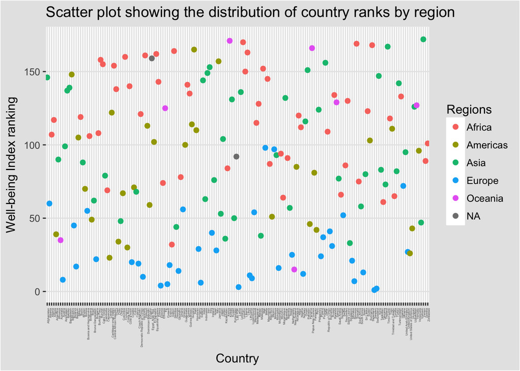

```r
final_score %>%
  ggplot(aes(x = CountryName,
             y = finalindex,
             colour=final_score$region))+
  geom_point(size=2, stat="identity") +
  labs(colour = "Regions",
       title = "Scatter plot showing the distribution of country ranks by region",
       x = "Country",
       y = "Well-being Index ranking")+
  theme_igray()+
  theme(axis.text.x = element_text(angle = 90, hjust = 1, size = 2.8))
```

# Plot showing the mean regional rank

Next, we looked at the mean of ranks per region and we can clearly see that the smaller ranks cluster in Europe.

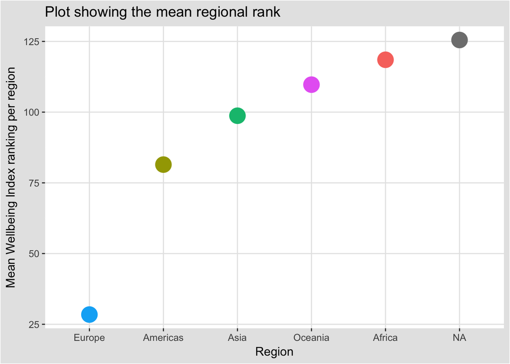

```r
a<- final_score %>%  group_by(region) %>% summarise(fi = mean(finalindex))

a %>%
  ggplot(aes(x = region,
             y = fi,
             colour = region))+
  geom_point(show.legend = FALSE, size = 7)+
  aes(x = fct_reorder(region,
                      fi))+
  labs(title = "Plot showing the mean regional rank",
       x = "Region",
       y = "Mean Wellbeing Index ranking per region")+
  theme_igray()
```